# Avaliação: Ajuste de modelo não linear

#### Pedro Moreira Neto, Tatiane Alves

### Dados

Os dados fornecidos para o desenvolvimento deste trabalho apresenta o número de *views* e *inscritos* desde o dia de sua abertura para dois canais de sucesso do youtube (Invento na hora e Voce Sabia?.

```r
data <- read.csv("youtube.txt", sep = " ", header = TRUE)
head(data)
```

```
##   DIAS VIEWS INSCRITOS         CANAL
## 1    1  5200        66 inventonahora
## 2    2  4600        89 inventonahora
## 3    3  5200       103 inventonahora
## 4    4  4400        87 inventonahora
## 5    5  5100       102 inventonahora
## 6    6  6200        93 inventonahora
```

```r
summary(data)
```

```
##       DIAS           VIEWS          INSCRITOS               CANAL
##  Min.   :  1.0   Min.   :    89   Min.   :    1   inventonahora:850
##  1st Qu.:183.0   1st Qu.: 25700   1st Qu.:  657   vocesabia    :607
##  Median :365.0   Median : 98024   Median : 2051
##  Mean   :374.9   Mean   :134516   Mean   : 2503
##  3rd Qu.:547.0   3rd Qu.:172000   3rd Qu.: 3887
##  Max.   :850.0   Max.   :934121   Max.   :14611
```

### Objetivo

O objetivo deste trabalho é predizer o número **acumulado** de inscritos em cada um destes canais para os próximos 365 dias. Sabendo disso, iremos modelar cada canal individualmente, para tal, é feita a divisão da base de dados conforme cada canal.

```r
inventonahora <- data[data$CANAL == "inventonahora", ]
vocesabia     <- data[data$CANAL == "vocesabia", ]
```

Uma vez que queremos prever a quantidade acumulada de inscritos no canal, criamos uma nova variável para conter essas informação.

```r
factor <- 100000
inventonahora$INSCR_CUMSUM  <- cumsum(inventonahora$INSCRITOS/factor)
vocesabia$INSCR_CUMSUM      <- cumsum(vocesabia$INSCRITOS/factor)
```

O modelo a ser minimizado é o modelo logístico de crescimento de bactérias e que se caracteriza pela função:
$$y = \frac{L}{1 + \exp(\beta( x - \beta0) )}$$

onde L é o valor máximo da curva, $\beta0$ é o valor de *x* no ponto médio da curva e $\beta$ é a declividade da curva. E a função de perda escolhida para realizar esse minimização foi a perda quadrática que é dado pelo somotarório do quadrado da diferenca entre o valores reais e os previstos:
$$\sum_{i=i}^n (y - \mu)^2$$

Em R, o modelo logístico com a função de perda quadrática pode ser implementado da seguinte maneira.

```r
f_logistic <- function(par, dias, insc){
  mu <- par[1] / (1 + exp(par[2] * ( dias - par[3])))
  SQ_logit <- sum( (insc - mu)^2 )
  return(SQ_logit)
}
```

#### Otimização e previsão para o canal Invento Na Hora.

Para cada canal iremos minimizar a função descrita acima de forma que possamos encontrar um modelo que melhor se ajustes aos dados. Para alcançar nosso objetivo, faremos uso da função de otimização implementada no R **optim**. Essa instrução recebe qual função será minizada, ou maximizada dependendo do problema, um conjunto de parâmetros pertinentes a função logística e devolve os betas e o erro mínimo que conseguiu encontrar.

```r
logisticMinimization <- optim(par = c(round(max(inventonahora$INSCR_CUMSUM)), 0, mean(inventonahora$INSCR_CUMSUM)),
             fn = f_logistic, dias = inventonahora$DIAS, insc = inventonahora$INSCR_CUMSUM)
logisticMinimization
```

```
## $par
## [1]  24.199630736  -0.007329529 630.201112259
##
## $value
## [1] 247.1551
##
## $counts
## function gradient
##      309       NA
##
## $convergence
## [1] 0
##
## $message
## NULL
```

Dados os pesos obtidos pela minimização da função, aplicamos eles nos dados em vista de prever qual será o número de inscritos acumulados no periodo de um ano e plotamos o resultado.

No gráfico abaixo observa-se o comportamento do dado real descrito pela linha preta e o ajuste do modelo nesses dados caracterizado pela linha vermelha. Destaca-se que a continuação da linha vermelha representa a previsão de como este canal irá se comportar nos próximos 365 dias. A previsão demonstra que o canal está crescendo mas num ritmo mais lento que nos meses anteriores.

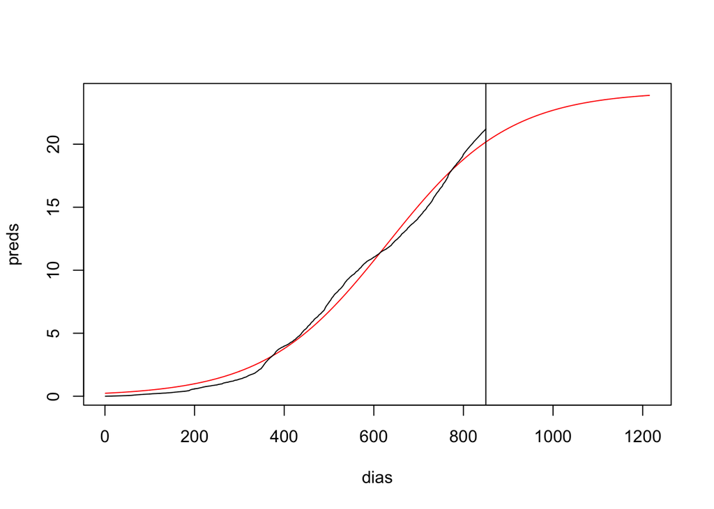

```r
dias <- seq(min(inventonahora$DIAS), max(inventonahora$DIAS) + 365, by=1)
preds <- logisticMinimization$par[1] / (1 + exp(logisticMinimization$par[2] * ( dias - logisticMinimization$par[3])))

plot(dias, preds,col="Red", type = "l")
lines(inventonahora$DIAS, inventonahora$INSCR_CUMSUM)
abline(v=max(inventonahora$DIAS))
```

#### Otimização e previsão para o canal Voce Sabia?

Semelhante ao canal **Invento Na Hora** iremos otimizar o modelo lógistico com base nos dados do canal **Voce Sabia?**. A otimização do modelo e previsão é dada pelo trecho de código abaixo.

```r
ols <- optim(par = c(round(max(vocesabia$INSCR_CUMSUM)), 0, mean(vocesabia$INSCR_CUMSUM)),
             fn = f_logistic, dias = vocesabia$DIAS, insc = vocesabia$INSCR_CUMSUM)


dias <- seq(min(vocesabia$DIAS), max(vocesabia$DIAS) + 365, by=1)
preditos <- ols$par[1] / (1 + exp(ols$par[2] * ( dias - ols$par[3])))
```

Como podemos ver no gráfico abaixo, ao contrário do canal Invento na Hora, o ajuste do modelos nos dados nos informa que este canal apesar de novo é provável que tenha um crescimento rápido no número de inscritos.

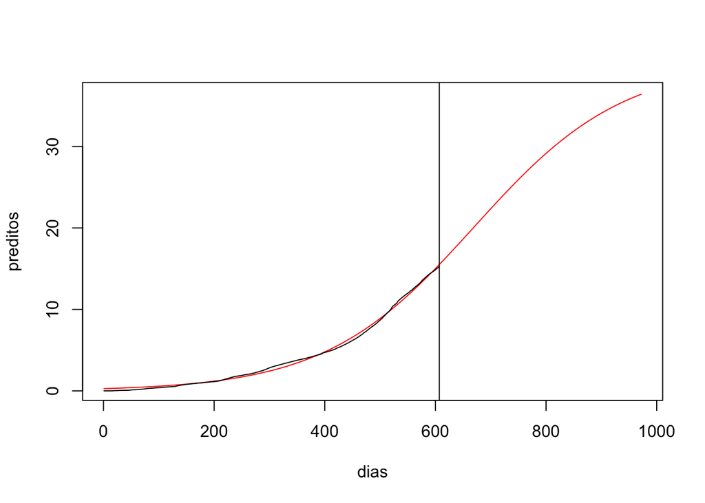

```r
plot(dias, preditos,col="Red", type = "l")
lines(vocesabia$DIAS, vocesabia$INSCR_CUMSUM)
abline(v=max(vocesabia$DIAS))
```